# Técnicas Clássicas de Reconhecimento de Padrões (2020/01)

# Exercício 01

## Ramon Gomes Durães de Oliveira (2019720188)

O exercício consiste na detecção de bordas em imagens aéreas da floresta amazônica utilizando filtros de borda binários num formato de redes neurais sem pesos, ou seja, simulando uma memória RAM. Em resumo, o trabalho foi conduzido da seguinte forma:

1. Amostragem visual de um pixel verde e um marrom
2. Binarização das imagens de acordo com a distância euclideana dos pixels com os pixels verde e marrom amostrados.
3. Detecção das bordas comparando a imagem binária com uma série de filtros de borda 3x3 definidos à mão.

### Preparação do ambiente

```python
import numpy as np
import matplotlib.pyplot as plt
%matplotlib inline
from PIL import Image
import glob
from scipy.spatial.distance import pdist

## Conversion script
#for image_name in glob.glob(".\\data\\*.jpg"):
#    split_name = image_name.split("\\")
#    new_name = split_name[0:-1]
#    print("rgb_"+split_name[-1])
#    new_name.append("rgb_"+split_name[-1])
#    print(new_name)
#    img = Image.open(image_name)
#    img.convert('RGB').save("\\".join(new_name), "PNG", optimize=True)
```

### Amostragem dos Pixels

#### Pixel verde ( a partir da imagem da floresta)

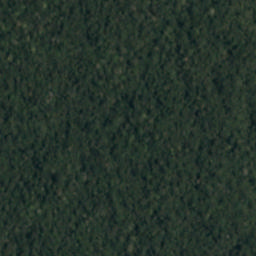

```python
img = Image.open(".\\data\\rgb_forest1.jpg")
img_array = np.array(img)
img
```

Escolhendo uma cor e visualizando a cor escolhida:

```python
green_pixel = img_array[220,220,:]
green_pixel
```

```
array([38, 57, 44], dtype=uint8)
```

```python
Image.fromarray(np.reshape(np.repeat(green_pixel.reshape(1,1,3), 1600,axis=1), (40,40,3)))
```

[output not shown]

#### Pixel marrom (escolhido {a partir de uma imagem com muita terra)

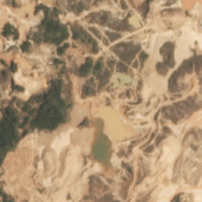

```python
img = Image.open(".\\data\\rgb_train_274.jpg")
img_array = np.array(img)
img
```

Escolhendo uma cor e visualizando a cor escolhida:

```python
brown_pixel = img_array[255,255,:]
brown_pixel
```

```
array([231, 205, 171], dtype=uint8)
```

```python
Image.fromarray(np.reshape(np.repeat(brown_pixel.reshape(1,1,3), 1600,axis=1), (40,40,3)))
```

[output not shown]

## Gerando as imagens binárias

```python
## Binarization script
for image_name in glob.glob(".\\data\\rgb_*.jpg"):
    split_name = image_name.split("\\")
    new_name = split_name[0:-1]
    new_name.append("bin_"+split_name[-1])
    img = Image.open(image_name)
    img_array = np.array(img)
    img_shape = img_array.shape
    bin_array = np.zeros((img_shape[0],img_shape[1]), dtype='uint8')
    for i in range(img_shape[0]):
        for j in range(img_shape[1]):
            dist_brown = np.abs(pdist((brown_pixel, img_array[i,j,:]))[0])
            dist_green = np.abs(pdist((green_pixel, img_array[i,j,:]))[0])
            bin_array[i,j] = 255 if (dist_green < dist_brown) else 0
    Image.fromarray(bin_array).save("\\".join(new_name), "PNG", optimize=True)
```

Visualizando um exemplo:

[output not shown]

### Definindo filtros de bordas binários manualmente

```python
filters = [# verticais
          #"100100100",
          "110110110",
          "010010010",
          #"001001001",
          "011011011",
           # horizontais
          #"111000000",
          "111111000",
          "000111000",
          "000111111",
          #"000000111",
           # diagonais horizontais
          #"100000000",
          #"110000000",
          "111100000",
          "111110000",
          #"111111100",
          #"111111110",
          #"011111111",
          #"001111111",
          "000011111",
          "000001111",
          #"000000011",
          #"000000001",
           # diagonais verticais
          #"100100000",
          #"110100100",
          "110110100",
          "111110110",
          #"111111110",
          #"001000000",
          #"001001000",
          "011001001",
          "011011001",
          "001011011",
          "001001011",
          "111011011",
          "111111011",
          "011011111",
           # diagonais
          "100010001",
          "100110111",
          "111011001",
          "001010100",
          "001011111",
          "111110100"]
```

### Extraindo bordas (janelas cujos "endereços" resultam numa posição de memória com 1)

```python
for image_name in glob.glob(".\\data\\bin_*.jpg"):
    split_name = image_name.split("\\")
    new_name = split_name[0:-1]
    print("edge_"+split_name[-1])
    new_name.append("edge_"+split_name[-1])
    img = Image.open(image_name)
    img_array = np.array(img)
    img_shape = img_array.shape
    edge_array = np.zeros((img_shape[0],img_shape[1]), dtype='uint8')
    window_size = 3
    for i in range(img_shape[0]-2):
        for j in range(img_shape[1]-2):
            window = img_array[i:i+3, j:j+3]/255
            address = "".join([str(int(x)) for x in window.flatten().tolist()])
            if address in filters:
                edge_array[i,j] = 255
    Image.fromarray(edge_array).save("\\".join(new_name), "PNG", optimize=True)
```

```
edge_bin_rgb_forest1.jpg
edge_bin_rgb_train_126.jpg
edge_bin_rgb_train_1591.jpg
edge_bin_rgb_train_1816.jpg
edge_bin_rgb_train_270.jpg
edge_bin_rgb_train_274.jpg
edge_bin_rgb_train_565.jpg
edge_bin_rgb_train_957.jpg
```

# Tabela de Resultados

[output not shown]

## Conclusão

O resultado obtido é interessante, especialmente se levarmos em consideração a simplicidade do método e seu baixo custo computacional e de memória. O resultado pode ainda ser melhorado utilizando técnicas mais maduras de binarização de imagens, escolhendo com maior cautela os filtros de borda e filtrando o resultado para que as bordas fiquem mais bem definidas.